# Stability Analysis of Cox Proportional Hazards Model

## Setup

```r
library(here)
library(survival)
library(ggplot2)
library(tidyr)
library(dplyr)
library(knitr)

# Source helper functions
source(here("R/cox-loglik.R"))
source(here("tests/test-helper-cox-loglik.R"))

# Set random seeds for reproducibility
seed_values <- c(123, 321, 231)
```

## Data Generation Process

We simulate survival data under two scenarios to systematically evaluate model stability:

1. **Without Offset**:
   - Covariates: $X_{i,j} \sim \mathcal{N}(0, 1)$
   - Survival times: $T_i \sim \text{Exp}(h_0 \cdot \exp(X_i \beta))$
   - Censoring: $\delta_i \sim \text{Bernoulli}(p_{\text{event}})$
2. **With Offset**:
   - Additional offset term: $O_i \sim \mathcal{N}(offsetMean, offsetSD^2)$
   - Survival times: $T_i \sim \text{Exp}(h_0 \cdot \exp(X_i \beta + O_i))$

Where: - $h_0 = 0.1$ (baseline hazard) - $p_{\text{event}} = 0.7$ (event probability) - $n = 1000$ observations - $p = 3$ covariates - True coefficients: β = (0.5, -0.3, 0.2)

We keep offsetMean = 2, vary offsetSD between 1 and 10

## Analysis Function

```r
run_analysis <- function(seed_value, beta_multiplier = 1, offset_mean = 2, offset_sd = 1) {
  set.seed(seed_value)
  n <- 1000
  p <- 3
  true_beta <- c(0.5, -0.3, 0.2) * beta_multiplier
  init_beta <- rep(0, p)

  # Without offset
  data_wo <- generate_cox_data(n = n, p = p, true_beta = true_beta, offset = 0)
  result_wo <- fit_custom_cox_model(init_beta, data_wo$time, data_wo$status,
                                  data_wo$covar, data_wo$strata, data_wo$offset)

  # Fit coxph without offset
  df_fit_wo <- data.frame(
    time = data_wo$time,
    status = data_wo$status,
    covar.1 = data_wo$covar[,1],
    covar.2 = data_wo$covar[,2],
    covar.3 = data_wo$covar[,3],
    offset = data_wo$offset
  )
  formula_wo <- as.formula("Surv(time, status) ~ covar.1 + covar.2 + covar.3 + offset(offset)")
  coxph_fit_wo <- coxph(formula_wo, data = df_fit_wo, control = coxph.control())
  cox_beta_wo <- coef(coxph_fit_wo)
  loglik_wo_cox_beta <- cox_loglik(
    beta = cox_beta_wo,
    time = data_wo$time,
    status = data_wo$status,
    covar = data_wo$covar,
    strata = data_wo$strata,
    offset = data_wo$offset
  )

  # With offset
  offset_vector <- rnorm(n, mean = offset_mean, sd = offset_sd)
  data_w <- generate_cox_data(n = n, p = p, true_beta = true_beta, offset = offset_vector)
  result_w <- fit_custom_cox_model(init_beta, data_w$time, data_w$status,
                                 data_w$covar, data_w$strata, data_w$offset)

  # Fit coxph with offset
  df_fit_w <- data.frame(
    time = data_w$time,
    status = data_w$status,
    covar.1 = data_w$covar[,1],
    covar.2 = data_w$covar[,2],
    covar.3 = data_w$covar[,3],
    offset = data_w$offset
  )
  formula_w <- as.formula("Surv(time, status) ~ covar.1 + covar.2 + covar.3 + offset(offset)")
  coxph_fit_w <- coxph(formula_w, data = df_fit_w, control = coxph.control())
  cox_beta_w <- coef(coxph_fit_w)
  loglik_w_cox_beta <- cox_loglik(
    beta = cox_beta_w,
    time = data_w$time,
    status = data_w$status,
    covar = data_w$covar,
    strata = data_w$strata,
    offset = data_w$offset
  )

  list(
    true_beta = true_beta,
    wo_offset = result_wo$par,
    w_offset = result_w$par,
    cox_wo_offset = cox_beta_wo,
    cox_w_offset = cox_beta_w,
    loglik_wo = result_wo$value,
    loglik_w = result_w$value,
    loglik_cox_wo = loglik_wo_cox_beta,
    loglik_cox_w = loglik_w_cox_beta
  )
}
```

## Results

### Results for comparing mult

```r
# Run analysis for different seeds and multipliers
results <- list()
for (offset_sd in c(1, 10)) {
  for (seed in seed_values) {
    results[[paste(seed, offset_sd)]] <- run_analysis(seed_value = seed, offset_sd = offset_sd)
  }
}
```

```r
source(here("scripts/TV-CSL/tests/test-helper.R"))

create_comparison_table <- function(results) {
  rows <- list()

  for (name in names(results)) {
    r <- results[[name]]
    seed_mult <- strsplit(name, " ")[[1]]

    # Calculate bias and RMSE for both custom and coxph
    bias_wo <- (r$wo_offset - r$true_beta) / r$true_beta
    bias_w <- (r$w_offset - r$true_beta) / r$true_beta
    bias_cox_wo <- (r$cox_wo_offset - r$true_beta) / r$true_beta
    bias_cox_w <- (r$cox_w_offset - r$true_beta) / r$true_beta

    rmse_wo <- sqrt(mean((r$wo_offset - r$true_beta)^2))
    rmse_w <- sqrt(mean((r$w_offset - r$true_beta)^2))
    rmse_cox_wo <- sqrt(mean((r$cox_wo_offset - r$true_beta)^2))
    rmse_cox_w <- sqrt(mean((r$cox_w_offset - r$true_beta)^2))

    # Calculate min and max relative errors
    rel_errors_wo <- calculate_relative_errors(r$true_beta, r$wo_offset)
    rel_errors_w <- calculate_relative_errors(r$true_beta, r$w_offset)
    rel_errors_cox_wo <- calculate_relative_errors(r$true_beta, r$cox_wo_offset)
    rel_errors_cox_w <- calculate_relative_errors(r$true_beta, r$cox_w_offset)


    rows[[name]] <- data.frame(
      Seed = seed_mult[1],
      offset_sd = seed_mult[2],
      RMSE_custom_wo = rmse_wo,
      RMSE_custom_w = rmse_w,
      RMSE_coxph_wo = rmse_cox_wo,
      RMSE_coxph_w = rmse_cox_w,
      max_rel_err_custom_wo = rel_errors_wo$max$max_relative_error,
      max_rel_err_custom_w = rel_errors_w$max$max_relative_error,
      max_rel_err_coxph_wo = rel_errors_cox_wo$max$max_relative_error,
      max_rel_err_coxph_w = rel_errors_cox_w$max$max_relative_error,
      LogLik_custom_wo = r$loglik_wo,
      LogLik_custom_w = r$loglik_w,
      LogLik_coxph_wo = r$loglik_cox_wo,
      LogLik_coxph_w = r$loglik_cox_w
    )
  }

  do.call(rbind, rows)
}
comparison_table_full <- create_comparison_table(results)

comparison_table <- comparison_table_full %>%
  select(Seed, offset_sd, ends_with("_w"))
library(kableExtra)
kable(comparison_table,
      digits = 4,
      caption = "Comparison of Models with Offset",
      format = "markdown",
      align = c('l', 'l', rep('r', 6))) %>%
  kable_styling(bootstrap_options = c("striped", "hover"))
```

Comparison of Models with Offset

|  | Seed | offset_sd | RMSE_custom_w | RMSE_coxph_w | max_rel_err_custom_w | max_rel_err_coxph_w | LogLik_custom_w | LogLik_coxph_w |
| --- | --- | --- | --- | --- | --- | --- | --- | --- |
| 123 1 | 123 | 1 | 0.0609 | 0.0609 | 0.5114 | 0.5114 | 4011.684 | 4011.684 |
| 321 1 | 321 | 1 | 0.0337 | 0.0337 | 0.2285 | 0.2285 | 3818.698 | 3818.698 |
| 231 1 | 231 | 1 | 0.0377 | 0.0377 | 0.1515 | 0.1515 | 3863.916 | 3863.916 |
| 123 10 | 123 | 10 | 0.0646 | 2.4607 | 0.5293 | 10.9273 | 2771.342 | 6978.399 |
| 321 10 | 321 | 10 | 0.0305 | 0.8822 | 0.2140 | 7.6185 | 2591.174 | 3339.623 |
| 231 10 | 231 | 10 | 933926.9804 | 1.4435 | 2922945.4498 | 7.6228 | 0.000 | 4420.454 |

## Visualization

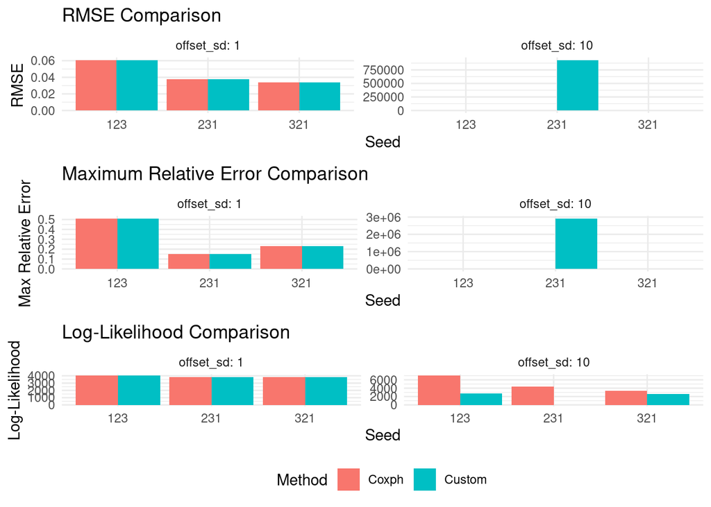

```r
create_comparison_plots <- function(comparison_table) {
  # Reshape data for plotting
  plot_data_rmse <- data.frame(
    Seed = comparison_table$Seed,
    offset_sd = as.numeric(comparison_table$offset_sd),
    Custom = comparison_table$RMSE_custom_w,
    Coxph = comparison_table$RMSE_coxph_w
  ) %>%
    tidyr::pivot_longer(cols = c(Custom, Coxph),
                       names_to = "Method",
                       values_to = "RMSE")

  plot_data_maxrel <- data.frame(
    Seed = comparison_table$Seed,
    offset_sd = as.numeric(comparison_table$offset_sd),
    Custom = comparison_table$max_rel_err_custom_w,
    Coxph = comparison_table$max_rel_err_coxph_w
  ) %>%
    tidyr::pivot_longer(cols = c(Custom, Coxph),
                       names_to = "Method",
                       values_to = "MaxRelError")

  plot_data_loglik <- data.frame(
    Seed = comparison_table$Seed,
    offset_sd = as.numeric(comparison_table$offset_sd),
    Custom = comparison_table$LogLik_custom_w,
    Coxph = comparison_table$LogLik_coxph_w
  ) %>%
    tidyr::pivot_longer(cols = c(Custom, Coxph),
                       names_to = "Method",
                       values_to = "LogLik")

  # Create individual plots
  p1 <- ggplot(plot_data_rmse,
               aes(x = factor(Seed), y = RMSE, fill = Method)) +
    geom_bar(stat = "identity", position = "dodge") +
    facet_wrap(~offset_sd, scales = "free_y",
               labeller = labeller(offset_sd = function(x) paste("offset_sd:", x))) +
    labs(title = "RMSE Comparison",
         x = "Seed",
         y = "RMSE") +
    theme_minimal() +
    theme(legend.position = "none")

  p2 <- ggplot(plot_data_maxrel,
               aes(x = factor(Seed), y = MaxRelError, fill = Method)) +
    geom_bar(stat = "identity", position = "dodge") +
    facet_wrap(~offset_sd, scales = "free_y",
               labeller = labeller(offset_sd = function(x) paste("offset_sd:", x))) +
    labs(title = "Maximum Relative Error Comparison",
         x = "Seed",
         y = "Max Relative Error") +
    theme_minimal() +
    theme(legend.position = "none")

  p3 <- ggplot(plot_data_loglik,
               aes(x = factor(Seed), y = LogLik, fill = Method)) +
    geom_bar(stat = "identity", position = "dodge") +
    facet_wrap(~offset_sd, scales = "free_y",
               labeller = labeller(offset_sd = function(x) paste("offset_sd:", x))) +
    labs(title = "Log-Likelihood Comparison",
         x = "Seed",
         y = "Log-Likelihood") +
    theme_minimal() +
    theme(legend.position = "bottom")

  # Combine plots
  combined_plot <- cowplot::plot_grid(
    p1, p2, p3,
    nrow = 3,
    align = "v",
    axis = "lr",
    rel_heights = c(1, 1, 1.2)  # Make bottom plot slightly taller to accommodate legend
  )

  return(combined_plot)
}

# Create and display the combined plot
combined_plots <- create_comparison_plots(comparison_table)
combined_plots
```

## Results and Discussion

### Impact of offset_sd

Large offset_sd causes coxph to fail, too. Custom lik generally handle it well, but sometimes (when seed == “231”), it failed to work at all (it stop at the first stage). Generally coxph could have problem when offset_sd is large and custom lik works well.

## TODO

1. Get clearer why ignoring large risk_sum could work. One way is to see when encountering large risk_sum, how many data it ignores and what is the next beta it run to.